# Sorter

När du planterar körsbär bör du se till att ha mer än en sort. Den främsta anledningen till detta är att många sötkörsbär kan inte befruktas av sig själva eller andra individer av samma sort. Sorterna måste vara genetiskt kompatibla med varandra och blomma samtidigt. Se sidan om pollination och pollinationsschemat för mer om det. Även de sorter som kan befrukta sig själva ger bättre skörd om de befruktas av andra.

Längst ner på den här sidan hittar du en sökbar tabell med synonymer för de körsbärssorter som finns med på den här webbplatsen.

## Varför plantera flera sorter?

- Kan vara nödvändigt för att få frukt (se ovan).
- Vissa sorter är lämpliga för matlagning och andra bör ätas färska.
- Om de mognar under olika perioder har du tillgång till körsbär under en längre tid.
- Olika sorter kan trivas olika bra i just din trädgård, så det kan vara bra att prova olika.

## Några egenskaper att ta hänsyn till

- Härdighet: Vilket klimat de kan odlas i. Anges ofta i zoner numrerade 1-8 där 1 är mildast och 8 kärvast. Kolla [zonkartan](https://www.plantagen.se/vaxtzoner.html) för att se vilken zon du bor i. Lokalt klimat kan påverkas av närhet till stora vatten (klimatet blir ofta mildare), läge osv.
- Läge: Behov av sol/möjlighet att växa i skugga.
- Motståndskraft mot sjukdomar.
- Blomningstid: Eftersom blommorna förstörs av frost bör blomningstiden anpassas till när sista frosten brukar vara där du bor.
- Motståndskraft mot att spricka vid rikligt sommarregn.
- Smak: Grad av sötma, syra, arom, etc.
- Storlek och form (vissa sorter är hjärtformade) på bären.
- Trädets utseende och storlek. Beror också på vilken *grundstam* som används.
- Skördens riklighet och tidpunkt (olika **mognadstid** ger längre skördesäsong).
- Färgen och glansen på skalet.
- Färgen på saften.
- Fruktköttets konsistens, saftighet och färg.
- Lämplighet för syltning, saftning, konservering, matlagning. I allmänhet är *surkörsbär* lämpade för syltning och konservering.
- Grundstam: Vilken grundstam sorten är ympad på.
- Tillgänglighet i handeln.
- Sötkörsbär kan ha svårt att klara de svenska förhållandena om de har annan härkomst och exempelvis har *odlats upp* vid varmare breddgrader.
- Kvalitetsmärkning. Vissa sorter finns som “E-plantor” (markeras med ett E efter namnet hos försäljaren). Se Ordboken för mer om det. [Här](https://eplanta.com/kategorier_hemtradgarden/tradgardens-skafferi/) kan du se vilka sorter av körsbär mm där E-märkta exemplar finns att köpa.
- Att välja åtminstone en självfertil sort gör att du är garanterad att få viss skörd.

# Surkörsbär

Surkörsbär (*Prunus cerasus*) har troligen uppkommit genom en korsning av sötkörsbär (*Prunus Avium*) och dvärgkörsbär (*P Fructiosa*).

De delas ibland in i *moreller/brunbär* (mörkröd färg och färgad saft) respektive *amareller/klarbär* (ljusare färg och ofärgad saft). De är ofta *självfertila* och blommar i allmänhet senare än sötkörsbär. Surkörsbären är syrligare än sötkörsbären och passar vanligen bättre för syltning och matlagning.

## Surkörsbär, skillnad mot sötkörsbär

- Mer syrliga än sötkörsbär.
- De flesta sorter av surkörsbär är självfertila (tex ‘Skuggmorell’), dvs kräver inte pollen från en annan individ för att bära frukt. Vissa är delvis- (tex ‘Kelleriis 16’) eller helt (tex ‘Tschernokorka’) själv-inkompatibla.
- Kräver mer kväve och vatten. Bättre tolerans mot dålig dränering av jorden.
- Mer motståndskraftiga mot skadeinsekter och sjukdomar.
- Blommar vanligen senare än sötkörsbär och är därför inte så lämpliga som pollinerare av dessa.
- Kan i allmänhet användas för syltning, saftning och matlagning.
- Är allotetraploider med 2n = 4x = 32 kromosomer dvs har två uppsättningar diploida koromosomer från olika arter. *Prunus ceracus* antas vara en hybrid som skapats genom “ickereducerade” (diploida) celler från *Prunus avium* och normala celler från *P fructiosa*. En tetraploid sort kan ha upp till fyra alleler/varianter i samma locus. Sötkörsbär är diploida, 2n=2x=16.

Det finns även “Duke cherries” som är framodlade korsningar mellan söt- och surkörsbär.

## Några surkörsbär

**Fanal**: Morell. Självfertil. Mycket sur och kraftig smak. Tysk.

**Kelleris 16 (syn. Morellenfeuer)**: Morell. Delvis självfertil. Mild, syrlig smak.

**Kirsa**: Amarell. Buske.

**Lettisk Låg**: Morell. Självfertil. Söta bär. Buske.

**Montmorency (syn. Königliche Amarelle)**: Amarell. Självfertil. Starkväxande. Fransk.

**Nordia**: Morell. Självfertil. Buske. Svensk.

**Ostheimer**: Morell. Självsteril. Buskformigt träd. Blommar tidigt. Tysk.

**Pernilla**: Morell. Självfertil. Buske. Svensk.

**Sikkola**: Amarell. Självfertil. Små bär.

**Skuggmorell**: Morell. Självfertil. Syrlig. Tysk.

**Tshernokorka**: Morell. Anges i vissa källor vara självfertil men enligt genetiska analyser är den inte det. Mycket sur. Starkväxande. Rysk.

# Grundstammar

Körbär ympas vanligen på en trädstam från en annan art (oftast genom *okulering*). Typen av grundstam påverkar bland annat:

- Trädets storlek
- Härdighet
- När trädet blommar
- När trädet börjar bära frukt
- Hur gammalt trädet kan bli
- Motståndskrft mot sjukdomar och skadedjur.

## Olika grundstammar för körsbär

Ett icke-ympat körsbärsträd blir kring 6 m högt beroende på sort.

För en grundstam kan anges till vilken % av standardträdets höjd (det som ympas på rotstocken) det blir.

**Colt**

- En hybrid från *Prunus avium* och *Prunus pseudocerasus*
- Medelstarkväxande.
- Sluthöjden 3.5-4.5 m efter 8 år (60-70% av standard). Kan hållas till 3 m med beskärning.
- God bördighet.
- Passar sämre för sorter med riklig produktion och leder då till små, defomerade bär. Man kan då avlägsa en del av blomknopparna för att minska problemet.
- Colts vigör påverkas inte av virus, medan Gisela 5 har en något mindre vigör om det är virusdrabbat.
- Ger frukt inom 1-2 (2-3?) år.
- Klarar något sämre jord än Gisela 5.
- Kräver stöd de första åren.
- Grundstammen kan skadas vid hård vinter, men blommorna har mindre risk för frostskada.
- Zon 1-3.

Vissa sorter av körsbär har rapporterats vara inkompatible med en viss grundstam. Symtom på detta kan komma efter många år (“fördröjd inkompatibilitet”). Colt har angetts vara inkompatibel med ‘Sam’ och ‘Van’.

**Gisela 5**

- “Giessen-serien”.
- En hybrid mellan *Prunus cerasus* (surkörsbär) and *Prunus canascens*.
- Ger mindre träd än colt.
- Höjden blir ca 3 m efter 5 år. Sluthöjden varierar beroende på körsbärssort, 2.5-3 m (40-50% av standard). Kan hållas till 2 m med beskärning.
- Placera träden 2.5-3 m ifrån varandra om denna grundstam används.
- Behöver stödpåle hela livet.
- Ger frukt efter 1-3 år (körsbär som inte är ympade vanligen 4-5 år).
- God härdighet (ymplingen avmognar tidigt).
- Tidigarelägger blomningen med några dagar och ökar därmed risken för froststkador på knoppar/blommor. Klarar dock hård vinterkyla bättre än Colt.
- Lägre träd (ökar risken för frosstkada).
- Zon 1-4(5).

**Prunus avium**

- Starkväxande
- Högre träd (kan vara svårplockad pga höjd), 20-30 m
- Kronans diameter ca 10 m. Upprätt, något pyramidal form (beror på ymplingen sort?)
- God förankring i jorden
- Något senare fruktsättning
- Zon 1-5
- Används ej för sötkörsbär (som ju är av arten *Prunus avium*).

**Prunus cerasus**

- Ger mindre något mer svagväxande träd.
- Både söt- och surkörsbär (*Prunus cerasus*)?

**Prunum mahaleb**

- Används ej för sötkörsbär (?)
- Zon 1-3
- För torra, sandiga jordar

# Beskrivning av sorter

Olika körbärssorter avnvänds för komersiellt bruk i olika utsträckning beroende på vilket land som odlar dem. Exempelvis, i Norge är de sorter som främst odlas ‘Lapins’ (~ 44%), ‘Van’, och ‘Sweetheart’, andra senmognande sorter, ‘Ulster’, och ‘Burlat’ som ympats på grundstammarna GiSelA 5 och GiSelA 6. Surkörsbär ‘Fanal’ och ‘Stevnsbaer’ odlas där på grundstammarna Colt och Mazzard.

## Några intressanta sorter

### Skuggmorell

*Prunus cerasus subsp. acida*

Synonymer: ‘Schattenmorelle’, ‘Gr. Lange Lotkirsche’, ‘Nordkirsche’, ‘Schwarze Kirsche von Montreux’, ‘Späte Morelle’

Enligt vissa källor är blomningen långvarig och att Skuggmorell därför är en lämplig pollinatör även för sötkörsbär.

### Lapins

Blomningstiden anges olika i olika källor. Troligen är det en tidigblommande sort vars blommor riskerar skadas av frost. Självfertil. Uppges i England blomma samtidigt som ‘Van’, ‘Summer Sun’ och ‘Penny’.

### Van

Bra pollinatör. Kan vara inkompatibel med grundstammen ‘Colt’, vilket kan ge problem efter några år.

### Sunburst

Medelsen blomning, självfertil, klarar zon 3-4. Kan kombineras med ‘Sam’.

### Stella

Kan vara ett lämpligt val om man bara vill plantera ett körsbärsträd. Sorten är självfertil, lätta att odla och en bra pollinatör.

### Sam

God smak. Mörkröd. Kan vara inkompatibel med grundstammen ‘Colt’, vilket kan ge problem efter några år.

Sam i kombination med Sunburst (Självfertil, samma blomningstid, fullt kompatibel; mognar samtidigt) eller Stella (självfertil, blommar ett steg tidigare, fullt kompatibel; mognar tidigare), eller Linda (samma blomningstid, fullt kompatibel; ej självfertil).

### Merton Glory

Synonymer: Merton Glory

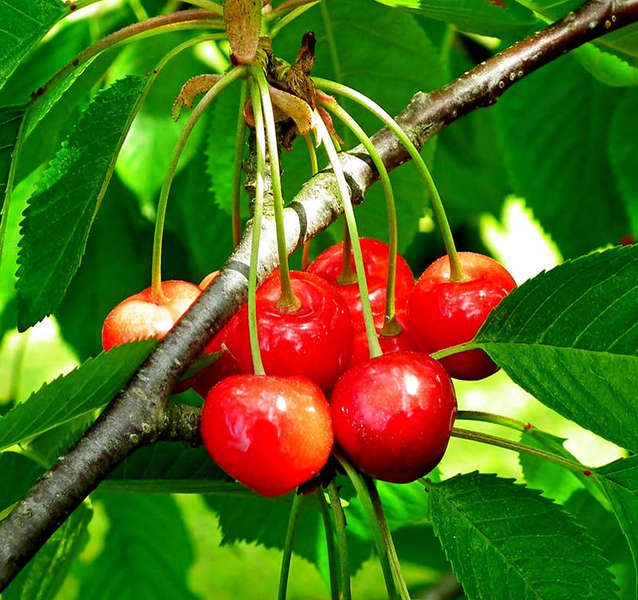

Merton Glory

Gulröd färg på skalet och gulvitt, mjukt kött som har hög sötma och medelhög syra. Blommar medeltidigt under blomningsperioden och mognar i mitten av mognadsperioden. Mognar tidigt. Bra pollinatör?.

### Andra sorter

**Allmän gulröd bigarrå**: God smak. Söt och syrlig. Kan användas för syltning.

**Fryksås** eller Gårdebo? Zon 4

Van: God. Zon 4.

Regina

# Lista synonymer

Många körsbär kallas med olika namn. Nedan finns en sökbar lista med synonymer. Varje kolumn kan filtreras med sökord. För att söka efter flera ord skriv “|” mellan dem.

| Sort | Synonym | Notering |
| --- | --- | --- |
| Allmän gulröd bigarrå | Gemeine Marmorkirsche, Allmän Gulröd |  |
| Almore | Almore |  |
| Annonay | Guinge la Plus Hative, Annonayer Herzkirsche, Guigne d'Annonay | Enligt vissa källor är Annonay (med ursprung I England, syn. Annonayer Herzkirsche) och Guigne d'Annonay (med ursprung I Frankrike, syn. Guinge la Plus Hative) olika sorter. |
| Berit | NA |  |
| Büttners Rote | Büttners Späte Rote Knorpelkirsche, Altenburger Melonen-kirsche, Heinrich Riesen, Altenburger Melonenkische, Büttners Späte Rote Knorpelkirsche, Heinrichs Riesen |  |
| Erianne | Erianne |  |
| Fanal | NA |  |
| Frogmore | Frogmore Bigarreau, Frogmore Early |  |
| Fryksås | Fryksås |  |
| Gårdebo | Gårdebo |  |

[output cut: 33 more lines]